# Recommendations with Movies

I. Exploratory Data Analysis  
II. Rank Based Recommendations  
III. User-User Based Collaborative Filtering

Let's get started by importing the necessary libraries and reading in the data.

```python
# import the necessary libraries
import pandas as pd
import numpy as np
import matplotlib.pyplot as plt
# import project_tests as t
import pickle
import seaborn as sns
sns.set()
%matplotlib inline

df = pd.read_csv('data/movies_clean.csv')
df_content = pd.read_csv('data/reviews_clean.csv')
del df['Unnamed: 0']
del df_content['Unnamed: 0']

# Show df to get an idea of the data
df.head()
```

|  | movie_id | movie | genre | date | 1800's | 1900's | 2000's | History | News | Horror | ... | Fantasy | Romance | Game-Show | Action | Documentary | Animation | Comedy | Short | Western | Thriller |
| --- | --- | --- | --- | --- | --- | --- | --- | --- | --- | --- | --- | --- | --- | --- | --- | --- | --- | --- | --- | --- | --- |
| 0 | 8 | Edison Kinetoscopic Record of a Sneeze (1894) | Documentary\|Short | 1894 | 1 | 0 | 0 | 0 | 0 | 0 | ... | 0 | 0 | 0 | 0 | 1 | 0 | 0 | 1 | 0 | 0 |
| 1 | 10 | La sortie des usines Lumière (1895) | Documentary\|Short | 1895 | 1 | 0 | 0 | 0 | 0 | 0 | ... | 0 | 0 | 0 | 0 | 1 | 0 | 0 | 1 | 0 | 0 |
| 2 | 12 | The Arrival of a Train (1896) | Documentary\|Short | 1896 | 1 | 0 | 0 | 0 | 0 | 0 | ... | 0 | 0 | 0 | 0 | 1 | 0 | 0 | 1 | 0 | 0 |
| 3 | 25 | The Oxford and Cambridge University Boat Race ... | NaN | 1895 | 1 | 0 | 0 | 0 | 0 | 0 | ... | 0 | 0 | 0 | 0 | 0 | 0 | 0 | 0 | 0 | 0 |
| 4 | 91 | Le manoir du diable (1896) | Short\|Horror | 1896 | 1 | 0 | 0 | 0 | 0 | 1 | ... | 0 | 0 | 0 | 0 | 0 | 0 | 0 | 1 | 0 | 0 |

5 rows × 35 columns

```python
# Show df_content to get an idea of the data
df_content.head()
```

|  | user_id | movie_id | rating | timestamp | date | month_1 | month_2 | month_3 | month_4 | month_5 | ... | month_9 | month_10 | month_11 | month_12 | year_2013 | year_2014 | year_2015 | year_2016 | year_2017 | year_2018 |
| --- | --- | --- | --- | --- | --- | --- | --- | --- | --- | --- | --- | --- | --- | --- | --- | --- | --- | --- | --- | --- | --- |
| 0 | 1 | 68646 | 10 | 1381620027 | 2013-10-12 23:20:27 | 0 | 0 | 0 | 0 | 0 | ... | 0 | 1 | 0 | 0 | 1 | 0 | 0 | 0 | 0 | 0 |
| 1 | 1 | 113277 | 10 | 1379466669 | 2013-09-18 01:11:09 | 0 | 0 | 0 | 0 | 0 | ... | 0 | 0 | 0 | 0 | 1 | 0 | 0 | 0 | 0 | 0 |
| 2 | 2 | 422720 | 8 | 1412178746 | 2014-10-01 15:52:26 | 0 | 0 | 0 | 0 | 0 | ... | 0 | 1 | 0 | 0 | 0 | 1 | 0 | 0 | 0 | 0 |
| 3 | 2 | 454876 | 8 | 1394818630 | 2014-03-14 17:37:10 | 0 | 0 | 0 | 0 | 0 | ... | 0 | 0 | 0 | 0 | 0 | 1 | 0 | 0 | 0 | 0 |
| 4 | 2 | 790636 | 7 | 1389963947 | 2014-01-17 13:05:47 | 0 | 0 | 0 | 0 | 0 | ... | 0 | 0 | 0 | 0 | 0 | 1 | 0 | 0 | 0 | 0 |

5 rows × 23 columns

### Part I : Exploratory Data Analysis

In this section of the notebook I will conduct exploratory data analysis.

`1.` What is the distribution of how many movies a user rated with in the dataset? Provide a visual and descriptive statistics to assist with giving a look at the number of times each user watched and rated amovies.

```python
# find number of columns and rows
df.shape
```

```
(31245, 35)
```

```python
# median
df.groupby('genre')['movie_id'].count().median()
```

```
2.0
```

```python
# max
df.groupby('genre')['movie_id'].count().max()
```

```
3529
```

```python
# median and maximum number of movie reviews
# 50% of individuals genre interact with 2 number of movies or fewer.
median_val = df.groupby('genre')['movie_id'].count().median()
# The maximum number of genre interactions by any 1 movie is 3529.
max_views_by_user = df.groupby('genre')['movie_id'].count().max()
```

```python
median_val
```

```
2.0
```

```python
max_views_by_user
```

```
3529
```

```python
movie_interacts = df.groupby('genre')['movie_id'].count()
movie_interacts
```

```
genre
Action                        213
Action|Adventure               58
Action|Adventure|Biography     18
Action|Adventure|Comedy       173
Action|Adventure|Crime         59
                             ...
Western|Drama                   2
Western|Fantasy                 1
Western|Horror                  1
Western|Mystery                 1
Western|Sci-Fi|Thriller         1
Name: movie_id, Length: 1180, dtype: int64
```

```python
# summary stats
movie_interacts.describe()
```

```
count    1180.000000
mean       26.289831
std       144.047022
min         1.000000
25%         1.000000
50%         2.000000
75%        11.000000
max      3529.000000
Name: movie_id, dtype: float64
```

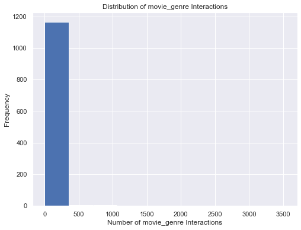

```python
# plot graph
plt.figure(figsize=(8,6))
movie_interacts.plot(kind='hist')
plt.title('Distribution of movie_genre Interactions')
plt.xlabel('Number of movie_genre Interactions');
```

`2.` Explore and remove duplicate movies from the **df_content** dataframe.

```python
# Find and explore duplicate Movies
df_content.head(3)
```

|  | user_id | movie_id | rating | timestamp | date | month_1 | month_2 | month_3 | month_4 | month_5 | ... | month_9 | month_10 | month_11 | month_12 | year_2013 | year_2014 | year_2015 | year_2016 | year_2017 | year_2018 |
| --- | --- | --- | --- | --- | --- | --- | --- | --- | --- | --- | --- | --- | --- | --- | --- | --- | --- | --- | --- | --- | --- |
| 0 | 1 | 68646 | 10 | 1381620027 | 2013-10-12 23:20:27 | 0 | 0 | 0 | 0 | 0 | ... | 0 | 1 | 0 | 0 | 1 | 0 | 0 | 0 | 0 | 0 |
| 1 | 1 | 113277 | 10 | 1379466669 | 2013-09-18 01:11:09 | 0 | 0 | 0 | 0 | 0 | ... | 0 | 0 | 0 | 0 | 1 | 0 | 0 | 0 | 0 | 0 |
| 2 | 2 | 422720 | 8 | 1412178746 | 2014-10-01 15:52:26 | 0 | 0 | 0 | 0 | 0 | ... | 0 | 1 | 0 | 0 | 0 | 1 | 0 | 0 | 0 | 0 |

3 rows × 23 columns

```python
df_content.shape
```

```
(712337, 23)
```

```python
# find duplicate timestamp and movies
print(df_content.timestamp.duplicated().sum())
print(df_content.movie_id.duplicated().sum())
```

```
2525
681092
```

```python
# Remove any rows that have the same timestamp - only keep the first
df_content.drop_duplicates(subset=['timestamp'], keep='first', inplace=True)
```

```python
# Remove any rows that have the same movie_id - only keep the first
df_content.drop_duplicates(subset=['movie_id'], keep='first', inplace=True)
```

```python
# check this works by pulling out an example
df_content.iloc[971]
```

```
user_id                      112
movie_id                   71360
rating                         9
timestamp             1377463774
date         2013-08-25 20:49:34
month_1                        0
month_2                        0
month_3                        0
month_4                        0
month_5                        0
month_6                        0
month_7                        0
month_8                        0
month_9                        0
month_10                       0
month_11                       0
month_12                       0
year_2013                      1
year_2014                      0
year_2015                      0
year_2016                      0
year_2017                      0
year_2018                      0
Name: 1373, dtype: object
```

`3.` Use the cells below to find:

**a.** The number of unique movies that have an interaction with a user.  
**b.** The number of unique genere in the dataset (whether they have any interactions or not).  
**c.** The number of unique users in the dataset. (excluding null values)  
**d.** The number of user-reviews interactions in the dataset.

```python
print(df.shape)
print(df_content.shape)
```

```
(31245, 35)
(31196, 23)
```

```python
# The number of unique Movies that have at least one interaction
df.movie_id.nunique()
```

```
31245
```

```python
# The number of unique genere on the movies platform
df.genre.nunique()
```

```
1180
```

```python
# The number of unique users
df_content.user_id.nunique()
```

```
6919
```

```python
# The number of movies interactions
df.shape[0]
```

```
31245
```

```python
# The number of movies_review interactions
df_content.shape[0]
```

```
31196
```

```python
unique_Movies = df.movie_id.nunique() # The number of unique movie that have at least one interaction
total_Movies =  df_content.user_id.nunique() # The number of unique user on the movies review platform
unique_users = df.genre.nunique() # The number of unique genre
user_Movies_interactions = df.shape[0] # The number of movies interactions
```

```python
# most viewed movie_id
df.movie_id.value_counts().head(2)
```

```
6211480    1
2106766    1
Name: movie_id, dtype: int64
```

```python
most_viewed_movie_id = str(df.movie_id.value_counts().index[0]) # The most viewed movie in the dataset as a string with one value following the decimal
max_views = df.movie_id.value_counts().iloc[0] # The most viewed movie in the dataset was viewed how many times?
```

```python
most_viewed_movie_id
```

```
'6211480'
```

```python
max_views
```

```
1
```

```python
## No need to change the code here - this will be helpful for later parts of the notebook
# Run this cell to map the user email to a user_id column and remove the email column

def genre_mapper():
    coded_dict = dict()
    cter = 1
    genre_encoded = []

    for val in df['genre']:
        if val not in coded_dict:
            coded_dict[val] = cter
            cter+=1

        genre_encoded.append(coded_dict[val])
    return genre_encoded

genre_encoded = genre_mapper()
del df['genre']
df['user_id'] = genre_encoded

# show header
df.head()
```

|  | movie_id | movie | date | 1800's | 1900's | 2000's | History | News | Horror | Musical | ... | Romance | Game-Show | Action | Documentary | Animation | Comedy | Short | Western | Thriller | user_id |
| --- | --- | --- | --- | --- | --- | --- | --- | --- | --- | --- | --- | --- | --- | --- | --- | --- | --- | --- | --- | --- | --- |
| 0 | 8 | Edison Kinetoscopic Record of a Sneeze (1894) | 1894 | 1 | 0 | 0 | 0 | 0 | 0 | 0 | ... | 0 | 0 | 0 | 1 | 0 | 0 | 1 | 0 | 0 | 1 |
| 1 | 10 | La sortie des usines Lumière (1895) | 1895 | 1 | 0 | 0 | 0 | 0 | 0 | 0 | ... | 0 | 0 | 0 | 1 | 0 | 0 | 1 | 0 | 0 | 1 |
| 2 | 12 | The Arrival of a Train (1896) | 1896 | 1 | 0 | 0 | 0 | 0 | 0 | 0 | ... | 0 | 0 | 0 | 1 | 0 | 0 | 1 | 0 | 0 | 1 |
| 3 | 25 | The Oxford and Cambridge University Boat Race ... | 1895 | 1 | 0 | 0 | 0 | 0 | 0 | 0 | ... | 0 | 0 | 0 | 0 | 0 | 0 | 0 | 0 | 0 | 2 |
| 4 | 91 | Le manoir du diable (1896) | 1896 | 1 | 0 | 0 | 0 | 0 | 1 | 0 | ... | 0 | 0 | 0 | 0 | 0 | 0 | 1 | 0 | 0 | 3 |

5 rows × 35 columns

```python
df_content.tail()
```

|  | user_id | movie_id | rating | timestamp | date | month_1 | month_2 | month_3 | month_4 | month_5 | ... | month_9 | month_10 | month_11 | month_12 | year_2013 | year_2014 | year_2015 | year_2016 | year_2017 | year_2018 |
| --- | --- | --- | --- | --- | --- | --- | --- | --- | --- | --- | --- | --- | --- | --- | --- | --- | --- | --- | --- | --- | --- |
| 711666 | 53962 | 2638984 | 10 | 1362510313 | 2013-03-05 19:05:13 | 0 | 0 | 0 | 0 | 0 | ... | 0 | 0 | 0 | 0 | 1 | 0 | 0 | 0 | 0 | 0 |
| 711717 | 53964 | 6054058 | 7 | 1498319844 | 2017-06-24 15:57:24 | 0 | 0 | 0 | 0 | 0 | ... | 0 | 0 | 0 | 0 | 0 | 0 | 0 | 0 | 1 | 0 |
| 711718 | 53964 | 6929642 | 6 | 1528709124 | 2018-06-11 09:25:24 | 0 | 0 | 0 | 0 | 0 | ... | 0 | 0 | 0 | 0 | 0 | 0 | 0 | 0 | 0 | 1 |
| 711719 | 53964 | 7392212 | 8 | 1522485346 | 2018-03-31 08:35:46 | 0 | 0 | 0 | 0 | 0 | ... | 0 | 0 | 0 | 0 | 0 | 0 | 0 | 0 | 0 | 1 |
| 712208 | 53966 | 3739110 | 7 | 1529882211 | 2018-06-24 23:16:51 | 0 | 0 | 0 | 0 | 0 | ... | 0 | 0 | 0 | 0 | 0 | 0 | 0 | 0 | 0 | 1 |

5 rows × 23 columns

### Part II: Rank-Based Recommendations

`1.` The function below returns the **n** top movie ordered with most interactions as the top.

```python
def get_top_movies(n, df=df):
    '''
    INPUT:
    n - (int) the number of top movies to return
    df - (pandas dataframe) df as defined at the top of the notebook

    OUTPUT:
    top_movies - (list) A list of the top 'n' movie titles

    '''
    top_movies = df['movie'].value_counts().index.tolist()[:n]
    top_movies = [str(i) for i in top_movies]

    return top_movies # Return the top movies titles from df (not df_content)

def get_top_movies_ids(n, df=df):
    '''
    INPUT:
    n - (int) the number of top movies to return
    df - (pandas dataframe) df as defined at the top of the notebook

    OUTPUT:
    top_movies - (list) A list of the top 'n' movie ids

    '''
    top_movies = df['movie_id'].value_counts().index.tolist()[:n]
    top_movies = [str(i) for i in top_movies]

    return top_movies # Return the top movie ids
```

```python
print(get_top_movies(10))
print(get_top_movies_ids(10))
```

```
['Home (2016)', 'The Visit (2015)', 'The Door (2012)', 'Unconditional (2012)', 'The D Train (2015)', 'Shelter (2014)', 'Beneath (2013)', 'Rush (2013)', 'This Is Our Time (2013)', 'Delirium (2018)']
['6211480', '2106766', '62868', '4363672', '5333612', '104984', '1424797', '59781', '4303202', '6903200']
```

### Part III: User-User Based Collaborative Filtering

`1.` The function below reformats the **df** dataframe to be shaped with users as the rows and movies as the columns.

- Each **user** should only appear in each **row** once.
- Each **movies** should only show up in one **column**.
- **If a user has interacted with an movies, then place a 1 where the user-row meets for that movie-column**. It does not matter how many times a user has interacted with the movie, all entries where a user has interacted with an movie should be a 1.
- **If a user has not interacted with an item, then place a zero where the user-row meets for that movie-column**.

```python
# create the user-movie matrix with 1's and 0's

def create_user_item_matrix(df):
    '''
    INPUT:
    df - pandas dataframe with movie_id, user_id columns

    OUTPUT:
    user_movies - user item matrix

    Description:
    Return a matrix with user ids as rows and movies ids on the columns with 1 values where a user interacted with
    an movie and a 0 otherwise
    '''
    df_count = df.groupby(['user_id', 'movie_id']).count().reset_index() # create a new df based on count
    user_item = df_count.pivot_table(values='movie', index='user_id', columns='movie_id') # pivot so users on rows and Movie on columns
    user_item.replace(np.nan, 0, inplace=True) # replace nulls with 0s
    user_item=user_item.applymap(lambda x: 1 if x > 0 else x) # entries should be a 1 or 0

    return user_item # return the user_item matrix

user_item = create_user_item_matrix(df)
```

`2.` The function below takes a user_id and provides an ordered list of the most similar users to that user (from most similar to least similar). The returned result does not contain the provided user_id, as we know that each user is similar to him/herself. Because the results for each user here are binary, it makes sense to compute similarity as the dot product of two users.

```python
def find_similar_users(user_id, user_item=user_item):
    '''
    INPUT:
    user_id - (int) a user_id
    user_item - (pandas dataframe) matrix of users by movies:
                1's when a user has interacted with an movie, 0 otherwise

    OUTPUT:
    similar_users - (list) an ordered list where the closest users (largest dot product users)
                    are listed first

    Description:
    Computes the similarity of every pair of users based on the dot product
    Returns an ordered

    '''
    # compute similarity of each user to the provided user
    dot_prod_users = user_item.dot(np.transpose(user_item))

    # sort by similarity
    sim_users = dot_prod_users[user_id].sort_values(ascending = False)

    # create list of just the ids
    most_similar_users = sim_users.index.tolist()

    # remove the own user's id
    most_similar_users.remove(user_id)

    return most_similar_users # return a list of the users in order from most to least similar
```

```python
# Do a spot check of your function
print("The 10 most similar users to user 1 are: {}".format(find_similar_users(1)[:10]))
print("The 5 most similar users to user 120 are: {}".format(find_similar_users(120)[:5]))
print("The 3 most similar users to user 999 are: {}".format(find_similar_users(999)[:3]))
```

```
The 10 most similar users to user 1 are: [405, 389, 390, 391, 392, 393, 394, 395, 396, 397]
The 5 most similar users to user 120 are: [389, 391, 392, 393, 394]
The 3 most similar users to user 999 are: [1181, 396, 390]
```

`3.` Now that we have a function that provides the most similar users to each user, we want to use these users to find movie we can recommend. The functions below return the movies we would recommend to each user.

```python
def get_movies_names(movie_ids, df=df):
    '''
    INPUT:
    movie_ids - (list) a list of movies ids
    df - (pandas dataframe) df as defined at the top of the notebook

    OUTPUT:
    movie_names - (list) a list of movie names associated with the list of movie ids
                    (this is identified by the title column)
    '''
    movie_names = []

    for idx in movie_ids:
        movie_names.append(df[df['movie_id']==float(idx)].max()['movie'])

    return movie_names # Return the movie names associated with list of movie ids


def get_user_movies(user_id, user_item=user_item):
    '''
    INPUT:
    user_id - (int) a user id
    user_item - (pandas dataframe) matrix of users by movies:
                1's when a user has interacted with an movie, 0 otherwise

    OUTPUT:
    movie_ids - (list) a list of the ,movie ids seen by the user
    movie_names - (list) a list of movie names associated with the list of movie ids

    Description:
    Provides a list of the movie_ids and movie titles that have been seen by a user
    '''
    movie_ids = user_item.loc[user_id][user_item.loc[user_id] == 1].index.astype('str')

    movie_names = []

    for idx in movie_ids:
        movie_names.append(df[df['movie_id']==float(idx)].max()['movie'])

    return movie_ids, movie_names # return the ids and names


def user_user_recs(user_id, m = 10):
    '''
    INPUT:
    user_id - (int) a user id
    m - (int) the number of recommendations you want for the user

    OUTPUT:
    recs - (list) a list of recommendations for the user

    Description:
    Loops through the users based on closeness to the input user_id
    For each user - finds movies the user hasn't seen before and provides them as recs
    Does this until m recommendations are found

    Notes:
    Users who are the same closeness are chosen arbitrarily as the 'next' user

    For the user where the number of recommended movies starts below m
    and ends exceeding m, the last items are chosen arbitrarily

    '''
    recs = np.array([]) # recommendations to be made

    user_movies_seen = get_user_movies(user_id)[0] #seen by our user
    closest_users = find_similar_users(user_id) # users closest to our user

    for others in closest_users:

        others_movies_seen = get_user_movies(others)[0] # movies seen by others like our user
        new_recs = np.setdiff1d(others_movies_seen, user_movies_seen, assume_unique=True) #find those not seen by user
        recs = np.unique(np.concatenate([new_recs, recs], axis = 0)) # concate arrays and only return unique values

        if len(recs) > m-1:
            break

    recs = recs[:m]
    recs.tolist()

    return recs # return your recommendations for this user_id
```

```python
# Check Results
get_movies_names(user_user_recs(1, 10)) # Return 10 recommendations for user 1
```

```
['Omega Doom (1996)',
 'Kansen rettô (2009)',
 'Gattaca (1997)',
 'Nirvana (1997)',
 "The Astronaut's Wife (1999)",
 'Under the Skin (2013)',
 'Monsters (2010)',
 'The Divide (2011)',
 'CLONED: The Recreator Chronicles (2012)',
 'Z for Zachariah (2015)']
```

`4.` Now we are going to improve the consistency of the **user_user_recs** function from above.

```python
def get_top_sorted_users(user_id, df=df, user_item=user_item):
    '''
    INPUT:
    user_id - (int)
    df - (pandas dataframe) df as defined at the top of the notebook
    user_item - (pandas dataframe) matrix of users by movies:
            1's when a user has interacted with an movies, 0 otherwise


    OUTPUT:
    neighbors_df - (pandas dataframe) a dataframe with:
                    neighbor_id - is a neighbor user_id
                    similarity - measure of the similarity of each user to the provided user_id
                    num_interactions - the number of movies viewed by the user - if a u

    Other Details - sort the neighbors_df by the similarity and then by number of interactions where
                    highest of each is higher in the dataframe

    '''
    # create neighbors dataframe with empty columns
    neighbors_df = pd.DataFrame(columns=['neighbor_id', 'similarity'])
    # set neighbor_id column equal to user_item index starting from 1
    neighbors_df['neighbor_id'] = user_item.index-1
    # make similarity column equal to most similar using dot product
    dot_prod_users = user_item.dot(np.transpose(user_item))
    neighbors_df['similarity'] = dot_prod_users[user_id]
    # create new df based on number of interactions of users
    interacts_df = df.user_id.value_counts().rename_axis('neighbor_id').reset_index(name='num_interactions')
    # merge dataframes which creates number of interactions column from interacts_df
    neighbors_df = pd.merge(neighbors_df, interacts_df, on='neighbor_id', how='outer')
    # sortvalues on similarity and then number of interactions
    neighbors_df = neighbors_df.sort_values(by=['similarity', 'num_interactions'], ascending = False)
    # reset index
    neighbors_df = neighbors_df.reset_index(drop=True)
    # drop row with the user_id as itself will be most similar
    neighbors_df = neighbors_df[neighbors_df.neighbor_id != user_id]

    return neighbors_df # Return the dataframe specified in the doc_string


def user_user_recs_part2(user_id, m=10):
    '''
    INPUT:
    user_id - (int) a user id
    m - (int) the number of recommendations you want for the user

    OUTPUT:
    recs - (list) a list of recommendations for the user by movie id
    rec_names - (list) a list of recommendations for the user by movie title

    Description:
    Loops through the users based on closeness to the input user_id
    For each user - finds movies the user hasn't seen before and provides them as recs
    Does this until m recommendations are found

    Notes:
    * Choose the users that have the most total movie interactions
    before choosing those with fewer movie interactions.

    * Choose movies with the movies with the most total interactions
    before choosing those with fewer total interactions.

    '''
    recs = np.array([]) # recommendations to be made

    user_movies_ids_seen, user_movies_names_seen = get_user_movies(user_id, user_item) #movie ids seen by our user
    closest_neighs = get_top_sorted_users(user_id, df, user_item).neighbor_id.tolist() # neighbour user ids closest to our user

    for neighs in closest_neighs:

        neigh_movies_ids_seen, neigh_movies_names_seen = get_user_movies(neighs, user_item) # movies seen by others like our user
        new_recs = np.setdiff1d(neigh_movies_ids_seen, user_movies_ids_seen, assume_unique=True) #find those not seen by user
        recs = np.unique(np.concatenate([new_recs, recs], axis = 0)) # concate arrays and only return unique values

        if len(recs) > m-1:
            break

    recs = recs[:m]
    recs = recs.tolist() # convert to a list

    rec_names = get_movies_names(recs, df=df)

    return recs, rec_names
```

```python
# Quick spot check - don't change this code - just use it to test your functions
rec_ids, rec_names = user_user_recs_part2(20, 10)
print("The top 10 recommendations for user 20 are the following movies ids:")
print(rec_ids)
print()
print("The top 10 recommendations for user 20 are the following movies names:")
print(rec_names)
```

[output not shown]

`5.` The functions from above are now used to correctly fill in the solutions to the dictionary below.

```python
### Tests with a dictionary of results

user1_most_sim = get_top_sorted_users(1).iloc[0].neighbor_id # Find the user that is most similar to user 1
user131_10th_sim = get_top_sorted_users(131).iloc[9].neighbor_id# Find the 10th most similar user to user 131
```

```python
user1_most_sim
```

```
20.0
```

```python
user131_10th_sim
```

```
123.0
```

`6.`

If given a new user, it would make sense to use Rank Based Recommendations and the `get_top_movies` function to make recommendations. We would just recommend the most popular movies since we do not have any information about the user or their interactions so cannot tell which other users they are most similar to. Once we have more information about the user we could a blended approach of 3 types of recommendation techniques; Rank, Content, and Collaborative.

`7.` Using our existing functions, we can provide the top 10 recommended movies we would provide for the a new user below.

```python
new_user = '0.0'
new_user_recs = get_top_movies_ids(10, df)
```

```python
new_user_recs
```

```
['6211480',
 '2106766',
 '62868',
 '4363672',
 '5333612',
 '104984',
 '1424797',
 '59781',
 '4303202',
 '6903200']
```